# Data Analysis and Visualization

## Ford GoBike System Data

#### by: Raffael Schlender

## Introduction

In this project, I investigated trip data of users in San Francisco Bay Area. The main focus was to wrangle and explore a `201902-fordgobike-tripdata` datafile by using Python visualization libraries, starting from plots of single variables and building up to plots of multiple variables. Now, I present the interesting relationships, patterns and insights that I discovered in the selected and cleaned dataset.

## Data

The Dataset consists of information regarding 183.412 bike trips, including its timing and geolocation of the start and end of each trip. The following features were primarily used in the investigation:

> - Bike Time Duration (minutes)
> - Start Time (hour of day) and Date (day of week)
> - User Type (Subscriber = Member or Customer = Casual)
> - Member Gender
> - Member Age

#### Data Cleaning

The most important data cleaning steps included:

> - Convert / correct data types
> - Remove data where bike time duration > 60 minutes
> - Create new variables like day of week, hour of day or member age
> - Delete illogical data

# Key Findings

## 1. Bike Time Duration

#### Observations

The distribution of biking durations is skewed. The range of data points are between 1 minute to 1400+ minutes. The average is around 12 minutes and the median at around 9 minutes. To make data visualization and interpretation easiler, outliers were removed. Below are the plots without and with a log scale.

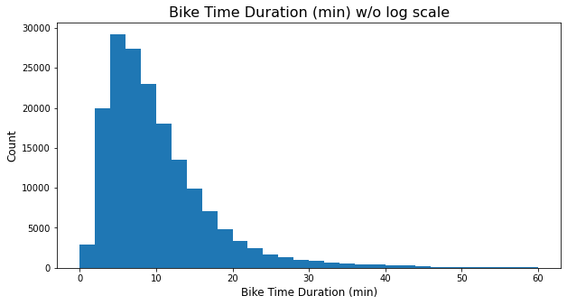

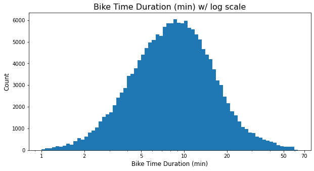

## 2. Age of Bikers

#### Observations

> - Most of the bikers are younger than 40 years, data peak at 32 years
> - Outliers where member age >60 years were removed

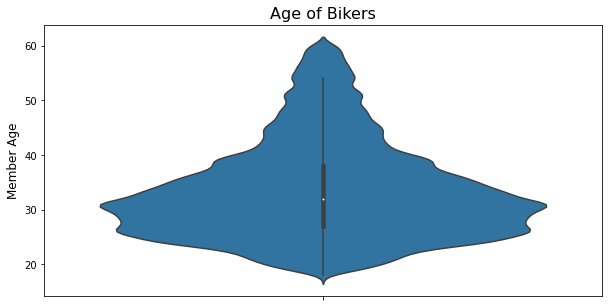

## 3. Bike Ride Trends

#### 3.1. Observations Weekday

> - Thursday has the most male and female bikers compared to other days. It also has the most subscriber bikers compared to other days.
> - The weekend has the lowest frequency of bike rides in term of gender and user type compared to the rest of the week.

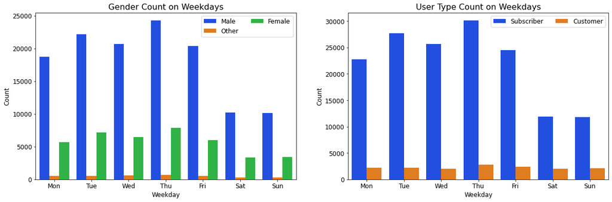

## 3. Bike Ride Trends

#### 3.2. Observations Time of Day

> - There are two starting spikes for bike trips over the day: Starts between 8:00 to 9:00 AM and starts between 17:00 to 18:00 PM.
> - Over the whole day, more male biker starts their trip than female riders.
> - Over the whole day, more Subscriber (Member) starts their bike rides than Customer bikers.
> - On Thursday the most bike trips are started.

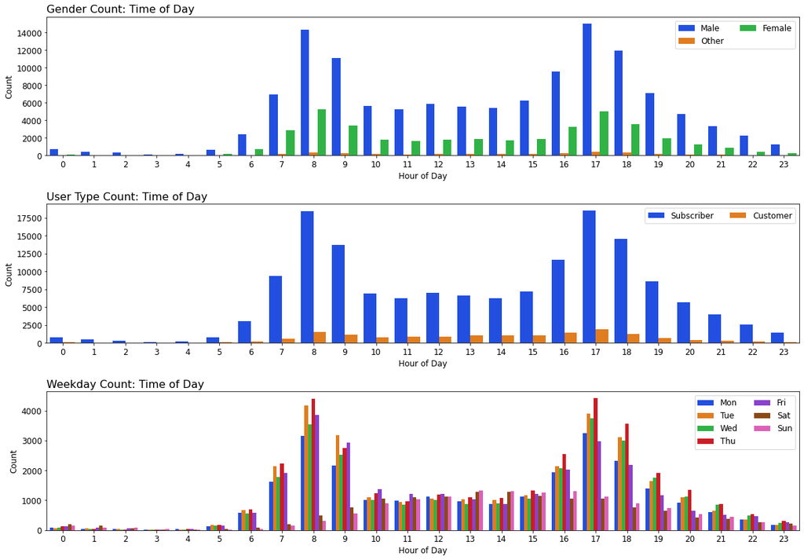

## 3. Bike Ride Trends

#### 3.3. Observations hourly usage: Customer vs. Subscriber

> - Subscribers mainly use the bike share service in the morning and in the evening from Monday to Friday. I think these people are mainly commuters.
> - Customers have a similar usage like Subscribers, but they also use the service more on the weekend. These users could mainly be tourists.

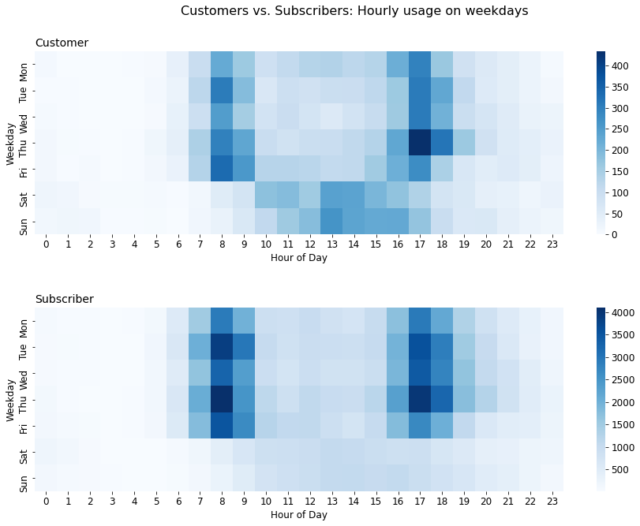

## 3. Bike Ride Trends

#### 3.4. Observations hourly usage: Male vs. Female

> - Overall, there are more male than female bikers, but the usage shows a similar pattern.

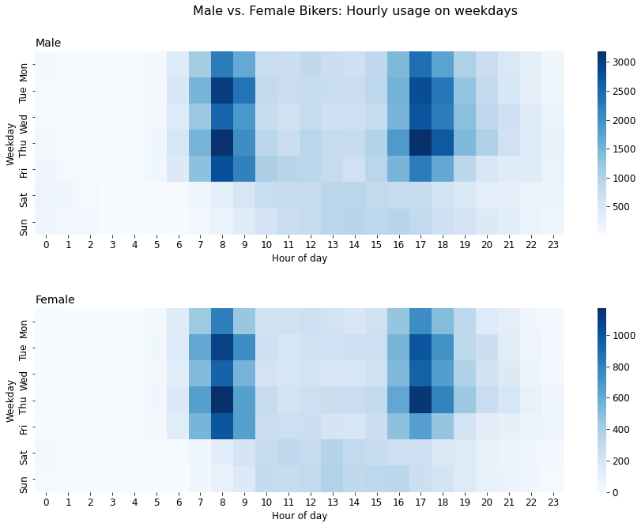